# Clase 15-01-2026

Cuando yo ya identifico los servicios criticos. Aquello que preservo con mi vida tengo que hacer una evaluacion de riesgos.

- Si tengo un server hay riesgo que se pierda la informacion
- Si tengo un servicio en la nube puede ser que la información se corrompa.
- Alguien podria apoderarse de el

Se debe de hacer un informe y decir que riesgos tiene.

### Normas

Iconect es una empresa que manda a un auditor que ceritifique las cosas del manual ISO de una empresa y vende las acreditaciones.

https://certiprof.com sirve para poder certificarse en esto.

El SCRUM Fundation que sirve para poder certificarse sobre SCRUM

## Gestores Documentales

Los gestores documentales son aquellos que sirven para dar un reporte de la normas y cumplimientos de una empresa

Una es OnBase pero hay mas

Sirve para clasificar el tipo de activos y la clasificacion que estos tiene

## Hacking Etico

La primera etapa y que veremos hoy es el reconocimiento.

En negocios la etapa de reconocimiento esta por empezar a conocer su infraestructura

Abre en tu navegador

[DNS DUMPSTER](https://dnsdumpster.com)

DNS DUMSPETER es un software que permite hace reconocimiento de una red.

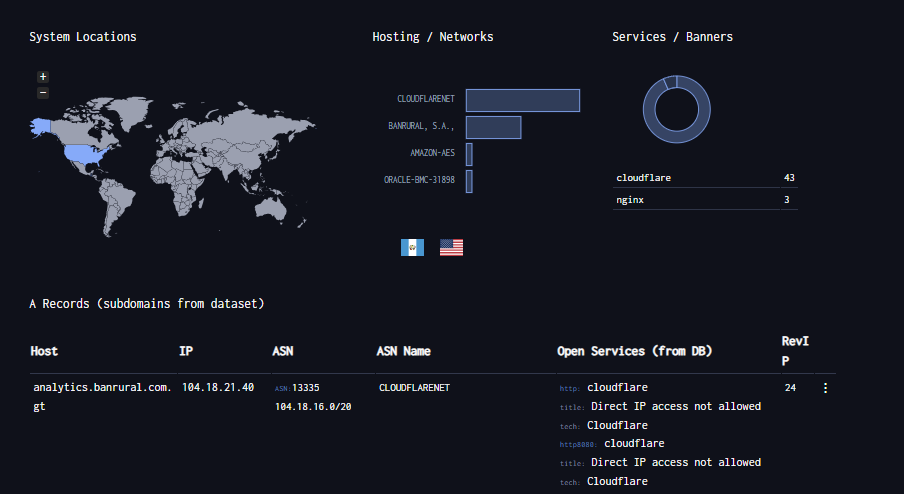

- Muestra el dominio
- Hosting
- Ubicacion
- Servicios utilizados

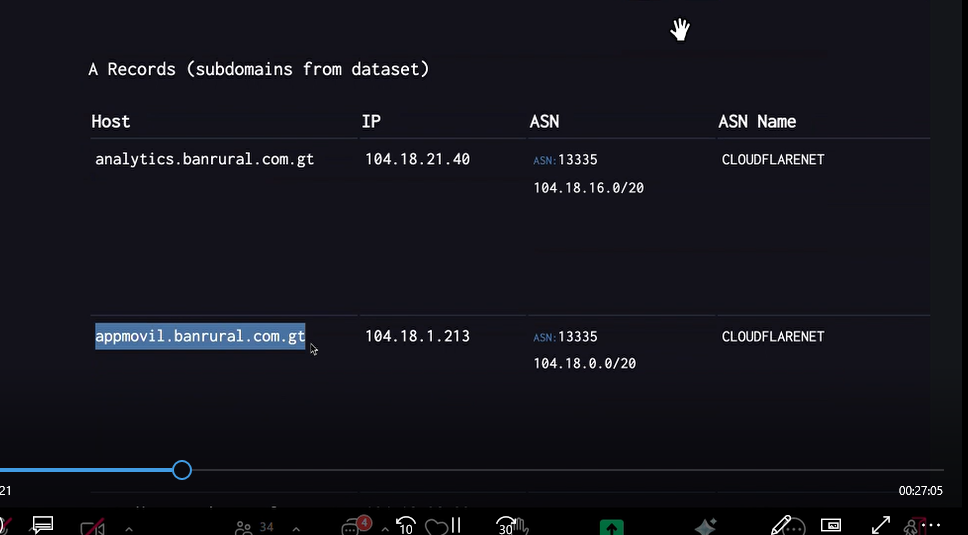

Esto si es una mala practica se sabe que ahi esta la app mobil y el dep de analytcs

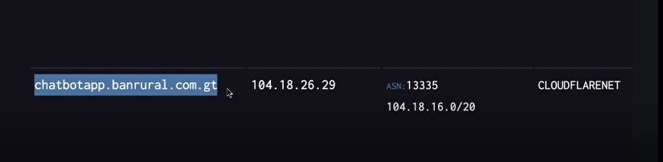

El problema es el chatbot que se puede si llegan a entrar modificarlo y pedirle datos al usuario y yo usarlo para meterme en sus cuentas

MX Recors son correos

TXT Records

Cofiguracion de servidor de correos electronicos

[figure not shown]

La U ves que tiene el servidor

[figure not shown]

Esto mira

[figure not shown]

Muestra hasta que tecnologias usan